# **Quantifying the Carbon Seesaw: A Hybrid Modeling Approach to Anthropogenic Emissions and Wildfire Volatility**

## *Presented as a California Wildfire Case Study*

## Angela Larson

Project page: https://angelalarson.github.io/angelalarson.github.io-main/project/project.html

Github page: https://github.com/angelalarson/angelalarson.github.io-main

**Project Goal:**

**Description of Datasets:**

The first dataset I will be using includes individual state and U.S. territory greenhouse gas emissions, grouped by greenhouse gas (Tg) and economic sector. These data range from years 1990-2022. Each row represents one greenhouse gas emission per year includes economic sector and subsectors, UNFCCC-IPCC sector and subsectors, carbon pool, fuel type, greenhouse gas type, and emission per year. This extensive dataset uses governmental language and is meant to inform emissions policies.

State greenhouse gas emissions data: U.S. Environmental Protection Agency (EPA) State Greenhouse Gas Inventory Dataset can be downloaded through the zip file under "Download state-level GHG data" section. https://www.epa.gov/ghgemissions/methodology-report-inventory-us-greenhouse-gas-emissions-and-sinks-state-1990-2022

The second dataset I will be using is California wildfire emissions data between the years of 2015-2024, compilied by the California Air Resources Board (CARB). Each row represents one wildfire event, represented by a unique wildfire ID and presents data on the number of acres burned, emissions, and fuel consumption data in addition to emissions per individual greenhouse gas (tons). These data are meant to support public knowledge of wildfire emissions and air quality risk.

California wildfire emissions data: California Air Resources Board (CARB) Wildfire Emissions Inventory Dataset can be downloaded by clicking on "Summary Table" under "Wildfire Emissions Data" section. https://ww2.arb.ca.gov/wildfire-emissions

California drought index data: Dataset can be downloaded by accessing "View More Statistics" and downloading the full dataset. https://droughtmonitor.unl.edu/CurrentMap/StateDroughtMonitor.aspx?CA

Generally, I aim to answer is how wildfire carbon dioxide emissions are dictated by wildfires and the role they play in all California emissions. Can these "unmanaged" emissions offset the climate mitigation gains achieved by reducing economic activity?

While the all-state greenhouse gas emissions dataset and drought index dataset includes a large breadth of data, the wildfire dataset is limited by its lack of national relevancy as who produced this dataset is the California-specific government sector California Air Resources Board. There is no standardized wildfire dataset to be found for each individual state, nor does this dataset exceed ten years worth of data. This has limited the depth of this data analysis and reproducibility per state.

## Extraction, Transform, and Load

```python
from google.colab import drive
drive.mount('/content/drive')

import os
os.chdir("/content/drive/MyDrive/cmps_project/") # changing file path to project folder
```

```python
# import required packages
import pandas as pd
import numpy as np
import matplotlib.pyplot as plt
import seaborn as sns
import warnings

# modeling
from sklearn.model_selection import train_test_split
from sklearn.linear_model import LinearRegression
from sklearn.metrics import mean_absolute_error, r2_score
from sklearn.feature_extraction import DictVectorizer
from sklearn.preprocessing import StandardScaler
from sklearn.model_selection import KFold, cross_validate
from sklearn.pipeline import Pipeline
from sklearn.neighbors import KNeighborsRegressor

warnings.filterwarnings('ignore')
```

```python
# load greenhouse gas dataset
ghg = pd.read_csv("AllStateGHGData90-22_v082924.csv")

# load wildfire emissions dataset
fires = pd.read_csv("Wildfire-Veg_EmissInv_2015-2024_Summary.csv")

# load drought severity dataset
drought = pd.read_csv("tableExport-2.csv")

# display beginning rows
display(ghg.head())
display(fires.head())
display(drought.head())
```

|  | sector | subsector | category | sub_category_1 | sub_category_2 | sub_category_3 | sub_category_4 | sub_category_5 | carbon_pool | fuel1 | ... | Y2013 | Y2014 | Y2015 | Y2016 | Y2017 | Y2018 | Y2019 | Y2020 | Y2021 | Y2022 |
| --- | --- | --- | --- | --- | --- | --- | --- | --- | --- | --- | --- | --- | --- | --- | --- | --- | --- | --- | --- | --- | --- |
| 0 | Agriculture | CO2 Emissions from Liming, Urea Application an... | Liming | Dolomite | NaN | NaN | NaN | NaN | NaN | NaN | ... | 0.000000 | 0.000000 | 0.000000 | 0.0 | 0.0 | 0.0 | 0.0 | 0.0 | 0.0 | 0.0 |
| 1 | Agriculture | CO2 Emissions from Liming, Urea Application an... | Liming | Dolomite | NaN | NaN | NaN | NaN | NaN | NaN | ... | 0.005047 | 0.000000 | 0.000000 | 0.0 | 0.0 | 0.0 | 0.0 | 0.0 | 0.0 | 0.0 |
| 2 | Agriculture | CO2 Emissions from Liming, Urea Application an... | Liming | Dolomite | NaN | NaN | NaN | NaN | NaN | NaN | ... | 0.002264 | 0.002704 | 0.003249 | 0.0 | 0.0 | 0.0 | 0.0 | 0.0 | 0.0 | 0.0 |
| 3 | Agriculture | CO2 Emissions from Liming, Urea Application an... | Liming | Dolomite | NaN | NaN | NaN | NaN | NaN | NaN | ... | 0.000000 | 0.000000 | 0.000000 | 0.0 | 0.0 | 0.0 | 0.0 | 0.0 | 0.0 | 0.0 |
| 4 | Agriculture | CO2 Emissions from Liming, Urea Application an... | Liming | Dolomite | NaN | NaN | NaN | NaN | NaN | NaN | ... | 0.000000 | 0.000000 | 0.000000 | 0.0 | 0.0 | 0.0 | 0.0 | 0.0 | 0.0 | 0.0 |

5 rows × 49 columns

|  | Year | Fire ID | Fire\nType | Start\nDate | End\nDate | Acres\nBurned | Total Fuels\nConsumed (tons) | TOG\n(tons) | TNMHC\n(tons) | NO2\n(tons) | SO2\n(tons) | CO\n(tons) | PM10\n(tons) | PM2.5\n(tons) | NH3\n(tons) | CO2\n(tons) | CH4\n(tons) | N2O\n(tons) | Involved Counties |
| --- | --- | --- | --- | --- | --- | --- | --- | --- | --- | --- | --- | --- | --- | --- | --- | --- | --- | --- | --- |
| 0 | 2015 | TANNER_objectid_3888 | suppression | 1/23/15 | 1/24/15 | 45.626 | 901.527 | 41.314 | 12.394 | 1.396 | 0.851 | 177.059 | 30.656 | 25.987 | 1.771 | 1332.413 | 8.263 | 0.186 | Placer |
| 1 | 2015 | MCOULLOH_objectid_3898 | suppression | 1/24/15 | 3/1/15 | 36.250 | 737.680 | 33.652 | 9.982 | 1.180 | 0.673 | 142.605 | 25.042 | 21.223 | 1.426 | 1095.129 | 6.843 | 0.153 | Placer |
| 2 | 2015 | SPRING-GARDEN_objectid_3948 | suppression | 2/6/15 | 2/6/15 | 16.012 | 177.126 | 7.755 | 2.380 | 0.287 | 0.177 | 34.000 | 5.848 | 4.961 | 0.340 | 263.033 | 1.497 | 0.037 | Plumas |
| 3 | 2015 | VAN-DYKE_000107 | suppression | 2/6/15 | 2/13/15 | 519.291 | 1403.665 | 46.451 | 13.523 | 3.402 | 1.117 | 193.179 | 32.288 | 27.368 | 1.932 | 2211.655 | 9.703 | 0.308 | Mono |
| 4 | 2015 | ROUND_001662 | suppression | 2/7/15 | 2/9/15 | 6549.296 | 17686.986 | 672.723 | 200.511 | 36.844 | 16.054 | 2864.439 | 479.356 | 406.712 | 28.644 | 27138.610 | 135.851 | 3.783 | Inyo, Mono |

|  | Week | None | D0-D4 | D1-D4 | D2-D4 | D3-D4 | D4 | DSCI |
| --- | --- | --- | --- | --- | --- | --- | --- | --- |
| 0 | 2000-01-04 | 51.83 | 48.17 | 0.0 | 0.0 | 0.0 | 0.0 | 48 |
| 1 | 2000-01-11 | 18.25 | 81.75 | 0.0 | 0.0 | 0.0 | 0.0 | 82 |
| 2 | 2000-01-18 | 27.96 | 72.04 | 0.0 | 0.0 | 0.0 | 0.0 | 72 |
| 3 | 2000-01-25 | 44.03 | 55.97 | 0.0 | 0.0 | 0.0 | 0.0 | 56 |
| 4 | 2000-02-01 | 49.12 | 50.88 | 0.0 | 0.0 | 0.0 | 0.0 | 51 |

**Start with cleaning the IPCC sector emissions dataset and subsetting for carbon dioxide emissions in California.**

```python
# clean greenhouse gas emission data
# find all year columns
year_cols = [c for c in ghg.columns if c.startswith('Y')]

# tidy data
ghg_long = ghg.melt(
    id_vars=[
        'geo_ref',
        'ghg',
        'ghg_category',
        'sector',
        'subsector',
        'category',
        'sub_category_1',
        'fuel1',
        'fuel2'
    ],
    value_vars=year_cols,
    var_name='year',
    value_name='emissions_Tg'
)

# clean year
ghg_long['year'] = ghg_long['year'].str.replace('Y','').astype(int)

# convert 0 emissions to NaN
ghg_long['emissions_Tg'] = ghg_long['emissions_Tg'].replace(0, np.nan)

# filter for CO2 only
ghg_long = ghg_long[ghg_long['ghg'] == 'Carbon Dioxide']

# subset California
ca_ghg = ghg_long[ghg_long['geo_ref'] == 'CA']

display(ca_ghg.head())
display(ca_ghg.dtypes)
```

|  | geo_ref | ghg | ghg_category | sector | subsector | category | sub_category_1 | fuel1 | fuel2 | year | emissions_Tg |
| --- | --- | --- | --- | --- | --- | --- | --- | --- | --- | --- | --- |
| 5 | CA | Carbon Dioxide | CO2 | Agriculture | CO2 Emissions from Liming, Urea Application an... | Liming | Dolomite | NaN | NaN | 1990 | 0.001105 |
| 62 | CA | Carbon Dioxide | CO2 | Agriculture | CO2 Emissions from Liming, Urea Application an... | Liming | Limestone | NaN | NaN | 1990 | 0.007981 |
| 119 | CA | Carbon Dioxide | CO2 | Agriculture | CO2 Emissions from Liming, Urea Application an... | Urea Fertilization | NaN | NaN | NaN | 1990 | 0.042583 |
| 4101 | CA | Carbon Dioxide | CO2 | Energy | Fossil Fuel Combustion | Commercial | NaN | Coal | NaN | 1990 | 0.044877 |
| 4254 | CA | Carbon Dioxide | CO2 | Energy | Fossil Fuel Combustion | Commercial | NaN | Natural Gas | NaN | 1990 | 15.663176 |

|  | 0 |
| --- | --- |
| geo_ref | object |
| ghg | object |
| ghg_category | object |
| sector | object |
| subsector | object |
| category | object |
| sub_category_1 | object |
| fuel1 | object |
| fuel2 | object |
| year | int64 |
| emissions_Tg | float64 |

**dtype:** object

Carbon dioxide is filtered for specifically due to it being the most common greenhouse gas and predominantly responsible for global warming as a result. Missing emissions are converted to NaNs to avoid use of zero values within the model.

```python
# highest emission states ranked
state_year = ghg_long.groupby(
    ['geo_ref','year']
)['emissions_Tg'].sum().reset_index()

# group dataset by state, select emissions and greenhouse gas, and sort the values from most to least
state_rank = state_year.groupby('geo_ref')['emissions_Tg'].mean().sort_values(ascending=False)

# display beginning rows
state_rank.head()
```

| geo_ref | emissions_Tg |
| --- | --- |
| TX | 633.235314 |
| CA | 353.892556 |
| FL | 237.544075 |
| OH | 234.440988 |
| PA | 229.824848 |

**dtype:** float64

```python
# emission change since 1990 per state
emissions_1990 = state_year[state_year['year'] == 1990]
emissions_recent = state_year[state_year['year'] == 2022]

# calculate change in emissions
delta_emission = emissions_recent.set_index('geo_ref')['emissions_Tg'] - emissions_1990.set_index('geo_ref')['emissions_Tg']

# rank largest change in emissions descending
display(delta_emission.sort_values(ascending=False).head(10))

display(delta_emission.sort_values(ascending=False).tail(10))
```

| geo_ref | emissions_Tg |
| --- | --- |
| TX | 133.765261 |
| FL | 52.878320 |
| AK | 36.511895 |
| AR | 31.653348 |
| National | 30.947326 |
| CO | 26.818079 |
| MS | 22.616880 |
| AZ | 20.840538 |
| MO | 18.906296 |
| MN | 14.985571 |

**dtype:** float64

| geo_ref | emissions_Tg |
| --- | --- |
| MD | -17.552479 |
| WV | -17.835779 |
| IL | -20.474443 |
| MA | -27.091614 |
| MI | -28.589308 |
| PA | -33.012370 |
| NY | -37.507267 |
| CA | -37.889885 |
| IN | -46.142872 |
| OH | -54.682378 |

**dtype:** float64

Initial exploration of this dataset includes change in carbon dioxide emissions between 1990 and 2022 for time series analysis. The states and territories that show decreases in emissions could reflect changes in policy or positive land use that increased carbon sinks, but more likely reflect a lack of emission accounting in earlier years. This provides me with context on how to better handle the data (ie, accounting for NaN values and only including specific years where all states are reflected). California is included in the states that have experienced carbon dioxide emissions reductions.

```python
# sector contributions nationally
sector_national = ghg_long.groupby('sector')['emissions_Tg'].sum()

display(sector_national)
```

| sector | emissions_Tg |
| --- | --- |
| Agriculture | 256.346786 |
| Energy | 176107.484617 |
| Energy-Excluded | 12528.757357 |
| Industrial Processes and Product Use | 6306.088915 |
| Land Use, Land-Use Change and Forestry | -32846.706024 |

**dtype:** float64

This provides great context as to which sectors result in the highest carbon dioxide emissions across the broader U.S. and compels me to look closer at certain sectors such as 'Land Use, Land-Use Change and Forestry' as it is negative. These values being negative is logical given that this includes carbon dioxide exchange in healthy forests, yet are interesting given widespread land use change.

```python
# sector contributions for California
sector_ca = ghg_long[ghg_long['geo_ref'] == 'CA'].groupby(
    'sector'
)['emissions_Tg'].sum()

display(sector_ca)
```

| sector | emissions_Tg |
| --- | --- |
| Agriculture | 4.122291 |
| Energy | 11392.693052 |
| Energy-Excluded | 1228.314445 |
| Industrial Processes and Product Use | 295.289987 |
| Land Use, Land-Use Change and Forestry | -1241.965424 |

**dtype:** float64

CA is apart of the states that are energy-emission dominated. Filtering for CA informs further investigation into CA-specific emission drivers as I build my model investigating how drought drives wildfires and wildfire emissions.

**Now clean the wildfire dataset.**

```python
# clean column names
# change 'Start\nDate' to 'start_date', 'CO\n(tons)' to 'co_(tons)', etc.
fires.columns = fires.columns.str.replace('\n', '_').str.strip().str.lower()
print(fires.columns)

# filter for specific columns
fires = fires[['acres_burned', 'co_(tons)', 'year', 'fire id', 'start_date', 'end_date']].copy()

# convert date columns to datetime objects for calculation
fires['start_date'] = pd.to_datetime(fires['start_date'])
fires['end_date'] = pd.to_datetime(fires['end_date'])

# new column of length of fire in days
fires['fire_length_days'] = (fires['end_date'] - fires['start_date']).dt.days
fires['year'] = fires['year'].astype(int)

# rename emission column
fires.rename(columns={'co_(tons)': 'wildfire_co2_ton'}, inplace=True)

display(fires.head())
display(fires.dtypes)
```

```
Index(['year', 'fire id', 'fire_type', 'start_date', 'end_date',
       'acres_burned', 'total fuels_consumed (tons)', 'tog_(tons)',
       'tnmhc_(tons)', 'no2_(tons)', 'so2_(tons)', 'co_(tons)', 'pm10_(tons)',
       'pm2.5_(tons)', 'nh3_(tons)', 'co2_(tons)', 'ch4_(tons)', 'n2o_(tons)',
       'involved counties'],
      dtype='object')
```

|  | acres_burned | wildfire_co2_ton | year | fire id | start_date | end_date | fire_length_days |
| --- | --- | --- | --- | --- | --- | --- | --- |
| 0 | 45.626 | 177.059 | 2015 | TANNER_objectid_3888 | 2015-01-23 | 2015-01-24 | 1 |
| 1 | 36.250 | 142.605 | 2015 | MCOULLOH_objectid_3898 | 2015-01-24 | 2015-03-01 | 36 |
| 2 | 16.012 | 34.000 | 2015 | SPRING-GARDEN_objectid_3948 | 2015-02-06 | 2015-02-06 | 0 |
| 3 | 519.291 | 193.179 | 2015 | VAN-DYKE_000107 | 2015-02-06 | 2015-02-13 | 7 |
| 4 | 6549.296 | 2864.439 | 2015 | ROUND_001662 | 2015-02-07 | 2015-02-09 | 2 |

|  | 0 |
| --- | --- |
| acres_burned | float64 |
| wildfire_co2_ton | float64 |
| year | int64 |
| fire id | object |
| start_date | datetime64[ns] |
| end_date | datetime64[ns] |
| fire_length_days | int64 |

**dtype:** object

```python
# convert date columns to datetime objects
drought['Week'] = pd.to_datetime(drought['Week'])

# merge based on the closest drought record
fires = fires.sort_values('start_date')
drought = drought.sort_values('Week')

# merge_asof is used to find the week that is closest to the start_date
both_df = pd.merge_asof(
    fires,
    drought[['Week', 'DSCI']],
    left_on='start_date',
    right_on='Week',
    direction='backward'
)

display(both_df)
```

|  | acres_burned | wildfire_co2_ton | year | fire id | start_date | end_date | fire_length_days | Week | DSCI |
| --- | --- | --- | --- | --- | --- | --- | --- | --- | --- |
| 0 | 45.626 | 177.059 | 2015 | TANNER_objectid_3888 | 2015-01-23 | 2015-01-24 | 1 | 2015-01-20 | 409 |
| 1 | 36.250 | 142.605 | 2015 | MCOULLOH_objectid_3898 | 2015-01-24 | 2015-03-01 | 36 | 2015-01-20 | 409 |
| 2 | 16.012 | 34.000 | 2015 | SPRING-GARDEN_objectid_3948 | 2015-02-06 | 2015-02-06 | 0 | 2015-02-03 | 409 |
| 3 | 519.291 | 193.179 | 2015 | VAN-DYKE_000107 | 2015-02-06 | 2015-02-13 | 7 | 2015-02-03 | 409 |
| 4 | 6549.296 | 2864.439 | 2015 | ROUND_001662 | 2015-02-07 | 2015-02-09 | 2 | 2015-02-03 | 409 |
| ... | ... | ... | ... | ... | ... | ... | ... | ... | ... |
| 3871 | 22.684 | 20.359 | 2024 | BORDER-79_00026957 | 2024-12-10 | 2024-12-11 | 1 | 2024-12-10 | 80 |
| 3872 | 7.784 | 3.261 | 2024 | MADERA_00106069 | 2024-12-11 | 2024-12-12 | 1 | 2024-12-10 | 80 |
| 3873 | 21.127 | 2.923 | 2024 | LEVEE_00001657 | 2024-12-23 | 2025-01-13 | 21 | 2024-12-17 | 80 |
| 3874 | 1.334 | 0.163 | 2024 | PINNACLE_00019350 | 2024-12-28 | 2024-12-28 | 0 | 2024-12-24 | 80 |
| 3875 | 43.145 | 18.857 | 2024 | OAK_00018805 | 2024-12-31 | 2024-12-31 | 0 | 2024-12-31 | 97 |

3876 rows × 9 columns

It is great to have the DSCI closest to each fire start date be aligned with each fire, however intense wildfires are the result of the cumulative effects of drought. The drier it gets, the higher danger for a wildfire. It may be more effective to predict wildfire emissions based on the prior month of DSCI values.

```python
# created fxn to calculate average DSCI for the 30 days leading up to the fire
def calculate_prior_dsci(fire_date, drought_data):
    # Define the window: (Start Date - 30 days) up to (Start Date)
    start_window = fire_date - pd.Timedelta(days=30)

    # Filter drought weeks within that window
    mask = (drought_data['Week'] >= start_window) & (drought_data['Week'] < fire_date)
    prior_weeks = drought_data.loc[mask, 'DSCI']

    # return the average DSCI in that window
    return prior_weeks.mean() if not prior_weeks.empty else None

# 3. Apply the function to create your new predictive column
both_df['dsci_avg_30d'] = both_df['start_date'].apply(lambda x: calculate_prior_dsci(x, drought))

# remove missing data (NaNs)
both_df = both_df.dropna(subset=['wildfire_co2_ton'])

display(both_df)
display(both_df.dtypes)
```

|  | acres_burned | wildfire_co2_ton | year | fire id | start_date | end_date | fire_length_days | Week | DSCI | dsci_avg_30d |
| --- | --- | --- | --- | --- | --- | --- | --- | --- | --- | --- |
| 0 | 45.626 | 177.059 | 2015 | TANNER_objectid_3888 | 2015-01-23 | 2015-01-24 | 1 | 2015-01-20 | 409 | 406.00 |
| 1 | 36.250 | 142.605 | 2015 | MCOULLOH_objectid_3898 | 2015-01-24 | 2015-03-01 | 36 | 2015-01-20 | 409 | 406.00 |
| 2 | 16.012 | 34.000 | 2015 | SPRING-GARDEN_objectid_3948 | 2015-02-06 | 2015-02-06 | 0 | 2015-02-03 | 409 | 409.25 |
| 3 | 519.291 | 193.179 | 2015 | VAN-DYKE_000107 | 2015-02-06 | 2015-02-13 | 7 | 2015-02-03 | 409 | 409.25 |
| 4 | 6549.296 | 2864.439 | 2015 | ROUND_001662 | 2015-02-07 | 2015-02-09 | 2 | 2015-02-03 | 409 | 409.25 |
| ... | ... | ... | ... | ... | ... | ... | ... | ... | ... | ... |
| 3871 | 22.684 | 20.359 | 2024 | BORDER-79_00026957 | 2024-12-10 | 2024-12-11 | 1 | 2024-12-10 | 80 | 81.75 |
| 3872 | 7.784 | 3.261 | 2024 | MADERA_00106069 | 2024-12-11 | 2024-12-12 | 1 | 2024-12-10 | 80 | 81.40 |
| 3873 | 21.127 | 2.923 | 2024 | LEVEE_00001657 | 2024-12-23 | 2025-01-13 | 21 | 2024-12-17 | 80 | 73.50 |
| 3874 | 1.334 | 0.163 | 2024 | PINNACLE_00019350 | 2024-12-28 | 2024-12-28 | 0 | 2024-12-24 | 80 | 76.75 |
| 3875 | 43.145 | 18.857 | 2024 | OAK_00018805 | 2024-12-31 | 2024-12-31 | 0 | 2024-12-31 | 97 | 76.75 |

3787 rows × 10 columns

|  | 0 |
| --- | --- |
| acres_burned | float64 |
| wildfire_co2_ton | float64 |
| year | int64 |
| fire id | object |
| start_date | datetime64[ns] |
| end_date | datetime64[ns] |
| fire_length_days | int64 |
| Week | datetime64[ns] |
| DSCI | int64 |
| dsci_avg_30d | float64 |

**dtype:** object

## Exploratory Data Analysis

```python
# summary statistics and measures of central tendency (rounded)
stats_df = both_df[['dsci_avg_30d', 'DSCI', 'wildfire_co2_ton', 'acres_burned']].describe().round(2)
display(stats_df)
```

|  | dsci_avg_30d | DSCI | wildfire_co2_ton | acres_burned |
| --- | --- | --- | --- | --- |
| count | 3787.00 | 3787.00 | 3787.00 | 3787.00 |
| mean | 167.14 | 169.72 | 9656.25 | 3511.99 |
| std | 153.70 | 154.19 | 101230.62 | 32007.00 |
| min | 1.00 | 1.00 | 0.00 | 0.22 |
| 25% | 30.50 | 30.00 | 3.90 | 11.56 |
| 50% | 129.00 | 130.00 | 23.00 | 34.03 |
| 75% | 311.00 | 314.00 | 166.53 | 177.80 |
| max | 431.50 | 433.00 | 4293145.19 | 1118913.61 |

The differences between these two DSCI measurements are marginal, but will be interesting to compare in a modeling context.

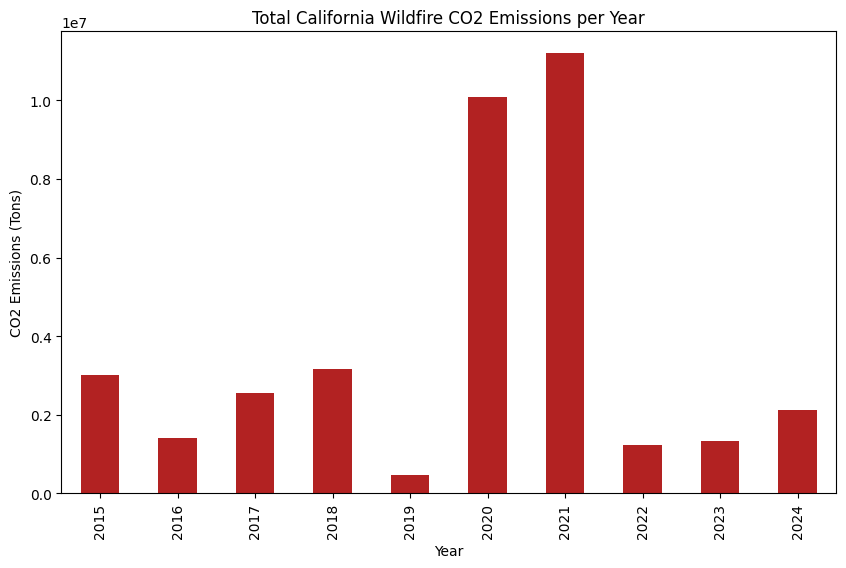

```python
# group by year at start date
annual_emissions = both_df.groupby(both_df['start_date'].dt.year)['wildfire_co2_ton'].sum()

# plot total wildfire co2 per year
annual_emissions.plot(kind='bar', color='firebrick', figsize=(10,6))
plt.title("Total California Wildfire CO2 Emissions per Year")
plt.ylabel("CO2 Emissions (Tons)")
plt.xlabel("Year")
plt.show()
```

This chart demonstrates the high interannual variability of wildfire emissions. Specifically, 2020 and 2021 are outliers with quite high CO2 emissions, associated with very high fire years. Emissions in these peak years exceeded 10 million metric tons, highlighting the impact of extreme fire events on the state's total carbon budget.

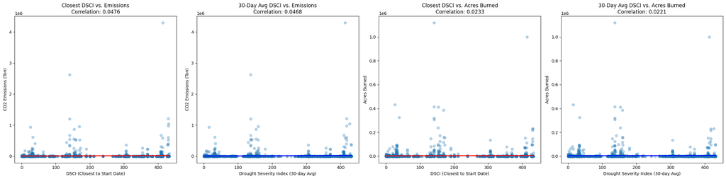

```
Numerical Correlation (Closest vs Emissions): 0.0476
Numerical Correlation (30-Day vs Emissions):  0.0468
Numerical Correlation (Closest vs Acres): 0.0233
Numerical Correlation (30-Day vs Acres):  0.0221
```

```python
# use .corr() to calc correlation coefficients (R)
corr_close_em = both_df['DSCI'].corr(both_df['wildfire_co2_ton'])
corr_30day_em = both_df['dsci_avg_30d'].corr(both_df['wildfire_co2_ton'])
corr_close_acres = both_df['DSCI'].corr(both_df['acres_burned'])
corr_30day_acres = both_df['dsci_avg_30d'].corr(both_df['acres_burned'])

# for side by side plots
fig, ax = plt.subplots(1, 4, figsize=(24, 6))

# plot 1: closest DSCI vs emissions
sns.regplot(data=both_df, x='DSCI', y='wildfire_co2_ton',
            scatter_kws={'alpha':0.3}, line_kws={'color':'red'}, ax=ax[0])
ax[0].set_title(f"Closest DSCI vs. Emissions\nCorrelation: {corr_close_em:.4f}")
ax[0].set_xlabel("DSCI (Closest to Start Date)")
ax[0].set_ylabel("CO2 Emissions (Ton)")

# plot 2: 30 day avg DSCI vs emissions
sns.regplot(data=both_df, x='dsci_avg_30d', y='wildfire_co2_ton',
            scatter_kws={'alpha':0.3}, line_kws={'color':'blue'}, ax=ax[1])
ax[1].set_title(f"30-Day Avg DSCI vs. Emissions\nCorrelation: {corr_30day_em:.4f}")
ax[1].set_xlabel("Drought Severity Index (30-day Avg)")
ax[1].set_ylabel("CO2 Emissions (Ton)")

# plot 3: closest DSCI vs acres
sns.regplot(data=both_df, x='DSCI', y='acres_burned',
            scatter_kws={'alpha':0.3}, line_kws={'color':'red'}, ax=ax[2])
ax[2].set_title(f"Closest DSCI vs. Acres Burned\nCorrelation: {corr_close_acres:.4f}")
ax[2].set_xlabel("DSCI (Closest to Start Date)")
ax[2].set_ylabel("Acres Burned")

# plot 4: 30 day avg DSCI vs acres
sns.regplot(data=both_df, x='dsci_avg_30d', y='acres_burned',
            scatter_kws={'alpha':0.3}, line_kws={'color':'blue'}, ax=ax[3])
ax[3].set_title(f"30-Day Avg DSCI vs. Acres Burned\nCorrelation: {corr_30day_acres:.4f}")
ax[3].set_xlabel("Drought Severity Index (30-day Avg)")
ax[3].set_ylabel("Acres Burned")

plt.tight_layout()
plt.show()

print(f"Numerical Correlation (Closest vs Emissions): {corr_close_em:.4f}")
print(f"Numerical Correlation (30-Day vs Emissions):  {corr_30day_em:.4f}")
print(f"Numerical Correlation (Closest vs Acres): {corr_close_acres:.4f}")
print(f"Numerical Correlation (30-Day vs Acres):  {corr_30day_acres:.4f}")
```

Initial exploratory data analysis was performed to assess the linearity of the relationship between DSCI and fire carbon dioxide emissions. Across all four relationships tested, the resulting Pearson correlations (R values) were quite low (r≈0.02 to 0.05). The horizontal regression lines and high residual variance suggest that drought acts more as a probabilistic pre-condition rather than a direct linear driver of fire size. Due to the lack of linearity found, I will pursue a K-NN model to model these relationships.

| drought_severity | wildfire_co2_ton mean | wildfire_co2_ton median | wildfire_co2_ton std | acres_burned mean | acres_burned median | acres_burned std |
| --- | --- | --- | --- | --- | --- | --- |
| Mild | 3884.000675 | 18.1120 | 33202.333683 | 1874.008367 | 33.137 | 15104.127740 |
| Moderate | 15181.318535 | 20.0015 | 119416.669194 | 6753.526119 | 40.921 | 49838.828678 |
| Severe | 13516.107118 | 38.2075 | 140162.529223 | 3426.810103 | 32.247 | 32501.410233 |

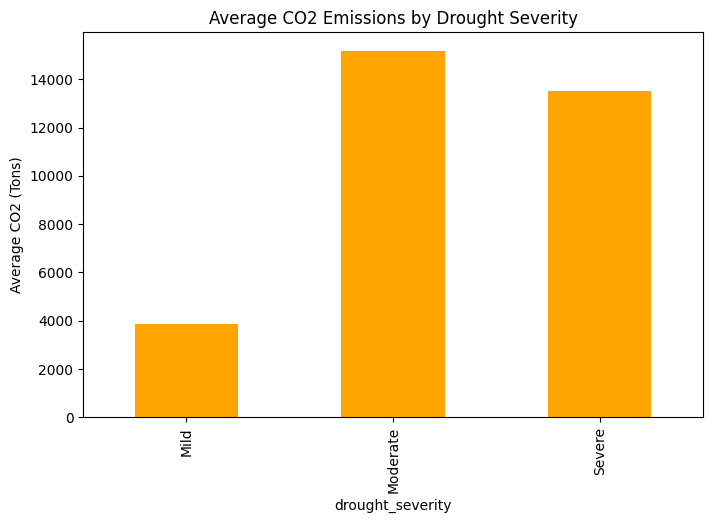

```python
# create categories for drought intensity
both_df['drought_severity'] = pd.cut(both_df['dsci_avg_30d'], bins=[0, 100, 300, 500],
                                     labels=['Mild', 'Moderate', 'Severe'])

# central tendency / summary table
drought_summary = both_df.groupby('drought_severity')[['wildfire_co2_ton', 'acres_burned']].agg(['mean', 'median', 'std'])
display(drought_summary)

# plot mean emissions by category
drought_summary['wildfire_co2_ton']['mean'].plot(kind='bar', color='orange', figsize=(8,5))
plt.title("Average CO2 Emissions by Drought Severity")
plt.ylabel("Average CO2 (Tons)")
plt.show()
```

**DSCI Groupings**

Mild = 0-100

Moderate = 100-300

Severe = 300-500

The initial aggregation of wildfire impact by categorical drought levels shows a "hump" in emissions as a result of Moderate DSCI having the highest carbon dioxide emissions. While moving from Mild to Moderate drought causes mean CO2 emissions to nearly quadruple with CO2 rising from approximately 3,884 to 15,181 tons. This trend does not continue linearly when rising to Severe drought. Instead, the mean emissions drop slightly to 13,516 tons in the highest drought category, suggesting that drought is not a simple linear driver of fire magnitude. Rather, it indicates that Moderate DSCI conditions may represent a "Goldilocks" situation. Too extreme drought conditions may result in a lack of fire fuel due to the foliage die off, leading to less extreme fire events.

|  | drought_severity | fire_count | wildfire_co2_ton |
| --- | --- | --- | --- |
| 0 | Mild | 1669 | 3884.000675 |
| 1 | Moderate | 876 | 15181.318535 |
| 2 | Severe | 1242 | 13516.107118 |

[figure not shown]

```python
# count for each drought bin
bin_counts = both_df.groupby('drought_severity')['fire id'].count().reset_index()
bin_counts.columns = ['drought_severity', 'fire_count']

# merge with existing emissions
emissions_means = both_df.groupby('drought_severity')['wildfire_co2_ton'].mean().reset_index()
comparison_df = bin_counts.merge(emissions_means, on='drought_severity')

display(comparison_df)

# plot
fig, ax1 = plt.subplots(figsize=(10, 6))

#primary axis: # of fires
sns.barplot(data=comparison_df, x='drought_severity', y='fire_count', alpha=0.6, color='gray', ax=ax1)
ax1.set_ylabel('Number of Fires (Sample Size)', color='gray')
ax1.set_title('Frequency of Fires vs. Mean Emissions by Drought Severity')

# secondary axis: avg emissions
ax2 = ax1.twinx()
sns.lineplot(data=comparison_df, x='drought_severity', y='wildfire_co2_ton', marker='o', color='darkorange', linewidth=3, ax=ax2)
ax2.set_ylabel('Mean CO2 Emissions (Tg)', color='darkorange')

plt.show()
```

By overlaying fire frequency with mean emissions, we can identify the intensity gap. Mild drought experiences the highest volume of individual fire events (1,669), yet these fires remain relatively small in their carbon footprint. Drought conditions aren't bad, so fires are easier to extinguish and don't grow as large.

In contrast, Moderate drought sees the lowest frequency of fires (876) but the highest average emissions per event. This suggests that while more fires occur under mild conditions, the "Moderate" drought conditions are characterized by fewer, but far more intensive emissions events. This specification is a key motivator for using k-NN modeling, as the model must distinguish between high-frequency baseline fires and low-frequency extreme events.

|  | drought_severity | fire_count | mean_acres |
| --- | --- | --- | --- |
| 0 | Mild | 1669 | 1874.008367 |
| 1 | Moderate | 876 | 6753.526119 |
| 2 | Severe | 1242 | 3426.810103 |

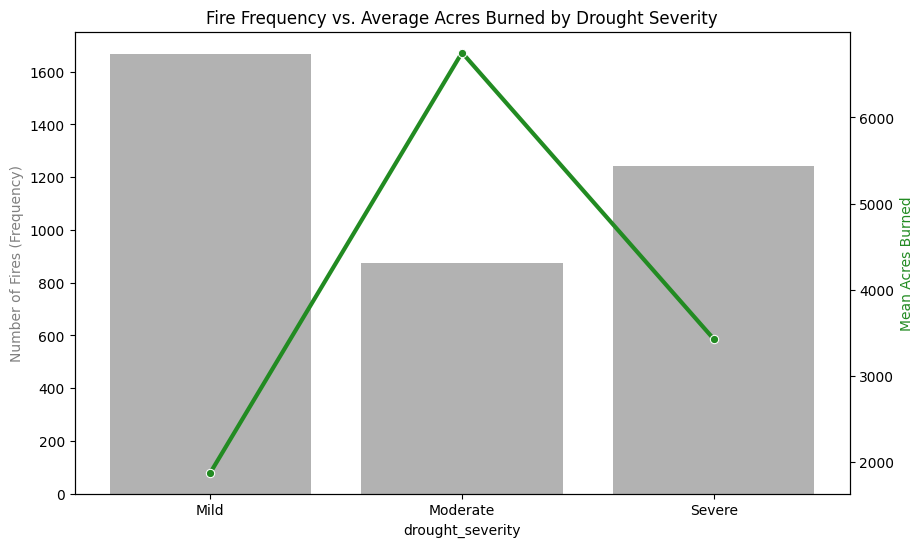

```python
# calc the counts and mean acreage for each drought bin
bin_counts = both_df.groupby('drought_severity', observed=False)['fire id'].count().reset_index()
acreage_means = both_df.groupby('drought_severity', observed=False)['acres_burned'].mean().reset_index()

# merge
acreage_comp = bin_counts.merge(acreage_means, on='drought_severity')
acreage_comp.columns = ['drought_severity', 'fire_count', 'mean_acres']

display(acreage_comp)

# plot
fig, ax1 = plt.subplots(figsize=(10, 6))

# primary axis: # of fires
sns.barplot(data=acreage_comp, x='drought_severity', y='fire_count', alpha=0.6, color='gray', ax=ax1)
ax1.set_ylabel('Number of Fires (Frequency)', color='gray')
ax1.set_title('Fire Frequency vs. Average Acres Burned by Drought Severity')

# secondary axis: avg acres
ax2 = ax1.twinx()
sns.lineplot(data=acreage_comp, x='drought_severity', y='mean_acres', marker='o', color='forestgreen', linewidth=3, ax=ax2)
ax2.set_ylabel('Mean Acres Burned', color='forestgreen')

plt.show()
```

The relationship between drought and acreage is similar to the emissions trend, but emphasizes the physical scale of these events. The peak in mean acres burned (6,753 acres) occurs under Moderate drought conditions, drastically outcompeting the average area burned in either Mild or Severe categories. The drop-off in acreage during Severe drought (3,426 acres) despite a relatively high fire count (1,242) potentially points to the "Goldilocks" theory presented earlier which is explained by fuel exhaustion or more aggressive suppression efforts during extreme drought years.

The main takeaway or story from these data is one of high variance and statistical outliers, emphasizing the need for a K-NN model than can handle non-linearity rather than regular linear regression.

## Modeling!

```
Optimal k for Emissions: 7
```

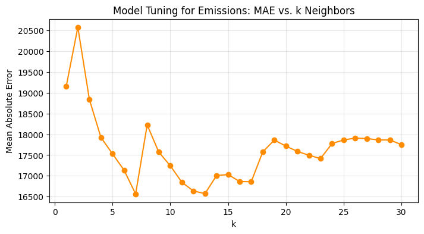

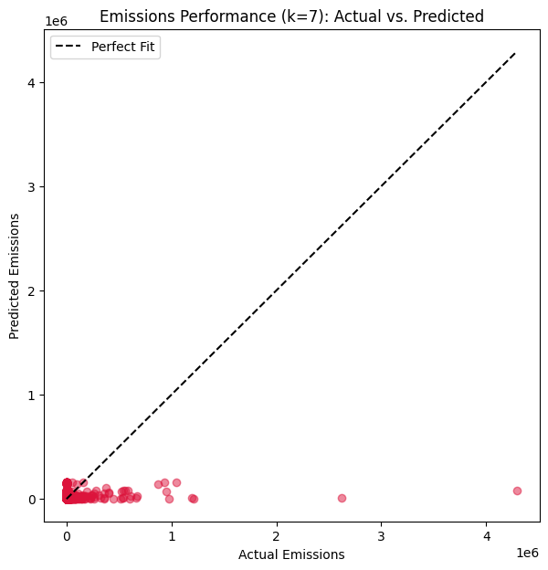

```
Optimal k for Acreage: 17
```

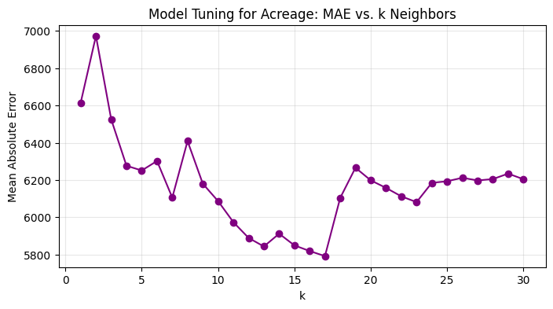

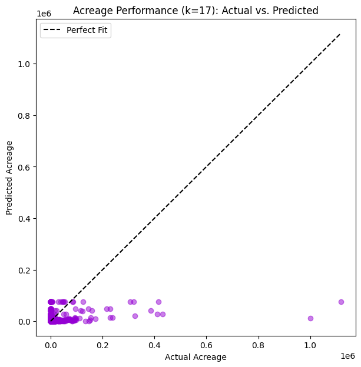

```python
# time for the model!

# set up features
# using 30 day prior average as preliminary tests saw it perform better
X_dict = both_df[['dsci_avg_30d']].to_dict(orient="records")
targets = {
    "Emissions": both_df['wildfire_co2_ton'],
    "Acreage": both_df['acres_burned']
}

# initialize tools
vec = DictVectorizer(sparse=False)
scaler = StandardScaler()

# hyperparameter tuning fxn
# using mae to account for large outliers
def get_cv_error_mae(k, y_target):
    model = KNeighborsRegressor(n_neighbors=k)
    pipeline = Pipeline([("vectorizer", vec), ("scaler", scaler), ("fit", model)])
    # Using neg_mean_absolute_error to reduce outlier influence
    mae_scores = cross_validate(
        pipeline, X_dict, y_target,
        cv=KFold(n_splits=5, shuffle=True, random_state=42),
        scoring="neg_mean_absolute_error"
    )["test_score"]
    return np.mean(-mae_scores)

# model tuning
ks = pd.Series(range(1, 31), index=range(1, 31))

# analysis fxn
def run_model_analysis(name, y, color_tuning, color_scatter):
    # Find optimal k using MAE
    errs = ks.apply(lambda k: get_cv_error_mae(k, y))
    best_k = errs.idxmin()
    print(f"Optimal k for {name}: {best_k}")

    # plot tuning curve
    plt.figure(figsize=(8, 4))
    errs.plot.line(marker='o', color=color_tuning)
    plt.title(f"Model Tuning for {name}: MAE vs. k Neighbors")
    plt.xlabel("k")
    plt.ylabel("Mean Absolute Error")
    plt.grid(True, alpha=0.3)
    plt.show()

    # model fit
    knn_final = KNeighborsRegressor(n_neighbors=best_k)
    pipeline_final = Pipeline([("vectorizer", vec), ("scaler", scaler), ("fit", knn_final)])
    pipeline_final.fit(X_dict, y)
    pred = pipeline_final.predict(X_dict)

    # plot model
    plt.figure(figsize=(7, 7))
    plt.scatter(y, pred, color=color_scatter, alpha=0.5)
    plt.plot([y.min(), y.max()], [y.min(), y.max()], 'k--', label="Perfect Fit")
    plt.title(f"{name} Performance (k={best_k}): Actual vs. Predicted")
    plt.xlabel(f"Actual {name}")
    plt.ylabel(f"Predicted {name}")
    plt.legend()
    plt.show()

    return pred

# apply across both y variables
_ = run_model_analysis("Emissions", targets["Emissions"], "darkorange", "crimson")
_ = run_model_analysis("Acreage", targets["Acreage"], "purple", "darkviolet")
```

These plots from the initial k-NN iterations reveal a fundamental inability of single-variable models to capture the impact of high-level wildfire events. While the model tuning curves for both Emissions (k=7) and Acreage (k=17) show significant variability and a lack of a clear U-shaped error convergence, the "Actual vs. Predicted" scatter plots expose a more important issue. The modeling is under-targeting predictions by failing to predict the presence of outlying events. This has created horizontal clustering near zero, leaving the model blind to the large outlier fires that drive California's carbon budget. Specifically, it is failing to predict any emissions over roughly 1 million tons despite some fires reaching above 4 million tons. This gap between predicted and actual emissions as fire magnitude increases is a clear indicator of heteroscedasticity, proving that simple linear scaling and limited feature sets cannot distinguish between baseline activity and extreme events. Ultimately, these results confirm that a single-parameter, linear approach to an exponential environmental crisis is insufficient and provides justification for moving toward a more complex, non-linear model.

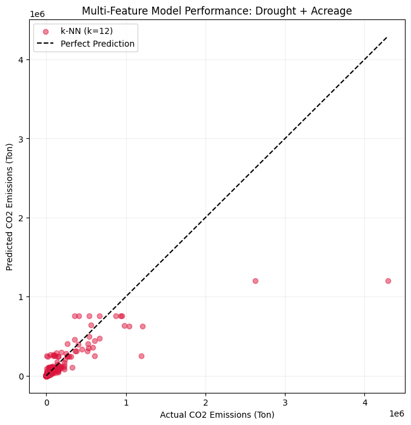

```
Model Results
Optimal k: 12
R^2 Score: 0.6270
```

```python
# improved model

# set up features
X_dict = both_df[['dsci_avg_30d', 'acres_burned']].to_dict(orient="records")
y_emissions = both_df['wildfire_co2_ton']

vec = DictVectorizer(sparse=False)
scaler = StandardScaler()

# hyperparameter tuning fxn
# using mae to account for large outliers
def get_cv_error_mae(k, X_data, y_target):
    model = KNeighborsRegressor(n_neighbors=k)
    pipeline = Pipeline([("vectorizer", vec), ("scaler", scaler), ("fit", model)])
    mae_scores = cross_validate(
        pipeline, X_data, y_target,
        cv=KFold(n_splits=5, shuffle=True, random_state=42),
        scoring="neg_mean_absolute_error"
    )["test_score"]
    return np.mean(-mae_scores)

# finding optimal k value
ks = pd.Series(range(1, 31), index=range(1, 31))
errs = ks.apply(lambda k: get_cv_error_mae(k, X_dict, y_emissions))
best_k = errs.idxmin()

# run model
knn_final = KNeighborsRegressor(n_neighbors=best_k)
pipeline_final = Pipeline([("vectorizer", vec), ("scaler", scaler), ("fit", knn_final)])
pipeline_final.fit(X_dict, y_emissions)
preds = pipeline_final.predict(X_dict)

# calc R^2
r2 = r2_score(y_emissions, preds)

# plot
plt.figure(figsize=(8, 8))
plt.scatter(y_emissions, preds, color='crimson', alpha=0.5, label=f'k-NN (k={best_k})')
plt.plot([y_emissions.min(), y_emissions.max()], [y_emissions.min(), y_emissions.max()],
         'k--', label="Perfect Prediction")

plt.title("Multi-Feature Model Performance: Drought + Acreage")
plt.xlabel("Actual CO2 Emissions (Ton)")
plt.ylabel("Predicted CO2 Emissions (Ton)")
plt.legend()
plt.grid(True, alpha=0.2)
plt.show()

print(f"Model Results")
print(f"Optimal k: {best_k}")
print(f"R^2 Score: {r2:.4f}")
```

The integration of a multi-feature k-NN model (k=12). By incorporating both drought severity and acreage, the model achieves an R^2 score of 0.6270, capturing much more variance than previously uncoupled models. Despite it more accurately identifying the upward trajectory of fire intensity, it is still under-targeting predictions for fires that exceed 2 million tons of carbon dioxide emissions. This demonstrates the constraint of a linear scale when dealing with data that is more accurately expressed as an exponential relationship. This model serves as a technical bridge for the project, validatingt the use of multiple parameters while identifying the necessity of log-transformation to accurately represent all corners of the data.

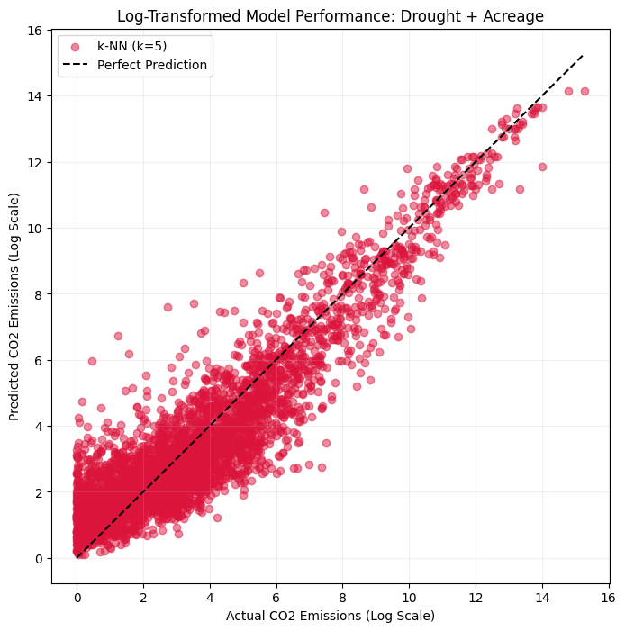

```
Model Results
Log-Transformed k: 5
Log-Transformed R^2: 0.8350
```

```python
# we will log transform to standardize the data and account for outliers
y_log = np.log1p(both_df['wildfire_co2_ton'])

# re-run tuning in case 'k' changes on a log scale
errs_log = ks.apply(lambda k: get_cv_error_mae(k, X_dict, y_log))
best_k_log = errs_log.idxmin()

# log the data
knn_log = KNeighborsRegressor(n_neighbors=best_k_log)
pipeline_log = Pipeline([("vectorizer", vec), ("scaler", scaler), ("fit", knn_log)])
pipeline_log.fit(X_dict, y_log)
preds_log = pipeline_log.predict(X_dict)

# plot
plt.figure(figsize=(8, 8))
plt.scatter(y_log, preds_log, color='crimson', alpha=0.5, label=f'k-NN (k={best_k_log})')
plt.plot([y_log.min(), y_log.max()], [y_log.min(), y_log.max()], 'k--', label="Perfect Prediction")

plt.title("Log-Transformed Model Performance: Drought + Acreage")
plt.xlabel("Actual CO2 Emissions (Log Scale)")
plt.ylabel("Predicted CO2 Emissions (Log Scale)")
plt.legend()
plt.grid(True, alpha=0.2)
plt.show()

print(f"Model Results")
print(f"Log-Transformed k: {best_k_log}")
print(f"Log-Transformed R^2: {r2_score(y_log, preds_log):.4f}")
```

The final model architecture, a multi-feature k-NN (k=5) with log-transformed targets, was specifically chosen to address the non-linear relationship and heteroscedasticity visualized in previous plots. By transitioning to a log-log scale as shown in the final scatter plot, we visualize how wildfire emissions growth is exponential rather than linear. This addresses the under-targeted prediction of large fires that were observed in previous graphs.

Here, we see much stronger correlation through the combination of both acres burned and DSCI in predicting wildfire emissions. The analysis strongly supports the conclusion that drought indices alone are insufficient predictors, whereas the inclusion of acreage alongside proper data transformation yields a robust R^2 score of 0.8350. We are able to effectively capture predictive signals through normalization of target distribution. While it is not perfect, it is much more symmetrical around the perfect prediction line.

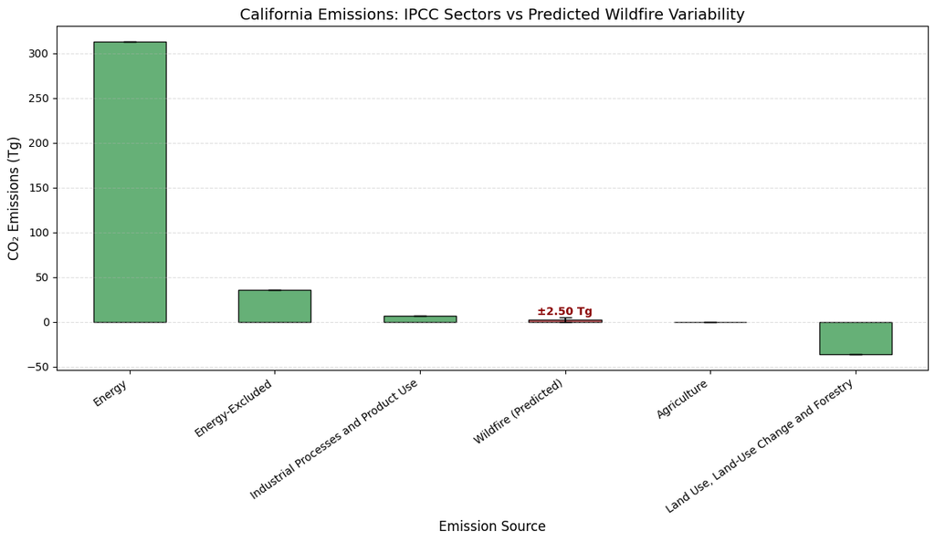

```python
both_df['predicted_wf_tons'] = np.expm1(preds_log)

# convert to Tg
both_df['predicted_wf_Tg'] = both_df['predicted_wf_tons'] / 1e6

# aggregate predicted wildfire emissions by year
wf_pred_annual = both_df.groupby(both_df['start_date'].dt.year)['predicted_wf_Tg'].sum()
wf_pred_annual = wf_pred_annual.reset_index()
wf_pred_annual.columns = ['year', 'predicted_wf_Tg']

# add sector totals
latest_year = 2022

sector_2022 = ca_ghg[ca_ghg['year'] == latest_year] \
    .groupby('sector')['emissions_Tg'].sum()

# predicted wildfire stats
wf_mean = wf_pred_annual['predicted_wf_Tg'].mean()
wf_std = wf_pred_annual['predicted_wf_Tg'].std()

# combine into one series
comp_series = sector_2022.copy()
comp_series['Wildfire (Predicted)'] = wf_mean

# error bar on wildfire to show model variability
errors = pd.Series(0.0, index=comp_series.index)
errors['Wildfire (Predicted)'] = wf_std

# sort for visual clarity
comp_series = comp_series.sort_values(ascending=False)
errors = errors[comp_series.index]

# plot
plt.figure(figsize=(12,7))

colors = ['#55a868' if 'Wildfire' not in x else '#c44e52' for x in comp_series.index]

comp_series.plot(
    kind='bar',
    yerr=errors,
    capsize=6,
    color=colors,
    edgecolor='black',
    alpha=0.9
)

plt.title(f"California Emissions: IPCC Sectors vs Predicted Wildfire Variability", fontsize=14)
plt.ylabel("CO₂ Emissions (Tg)", fontsize=12)
plt.xlabel("Emission Source", fontsize=12)
plt.xticks(rotation=35, ha='right')
plt.grid(axis='y', linestyle='--', alpha=0.4)

# annotate wildfire uncertainty
wf_index = list(comp_series.index).index('Wildfire (Predicted)')
plt.text(
    wf_index,
    comp_series['Wildfire (Predicted)'] + wf_std,
    f'±{wf_std:.2f} Tg',
    ha='center',
    va='bottom',
    fontweight='bold',
    color='darkred'
)

plt.tight_layout()
plt.show()
```

Improvement upon this model can resolve specific issues regarding wildfire prediction. For example, the inclusion of meterological forcing data such as wind speed would explain the speed at which a fire burns and likely has a larger role in acres burned.